# Criminal Justice Dissertation Topic Analysis

Connor Concannon

2016-11-06

## Introduction

Months ago, I was perusing the [American Society of Criminology’s](http://asc41.com) website and came across a [list of recent dissertations](http://www.asc41.com/graduates1.htm), including topics, authors, and instutitions.

The list was interesting to me for a few reasons. One, I need to begin thinking about a dissertation topic, and I would like to get a sense of recent dissertations, without having to actually read them. Two, the list was an opportunity to do some exploratory analysis and use some techniques and packages that I am not too familiar with, namely web scraping. And three, I could use this as an opportunity to publish a quick analysis and begin building a portfolio of analytical projects that are not necessarily work-related.

First, load a bunch of libraries.

[output not shown]

## Scraping and Cleaning

Next, I take the url, extract the data and clean it up quite a bit. I have never tried any webscraping, but rvest makes it seem easy. I am sure this can be improved, chained into a neater workflow, errors removed, etc., but I am not striving for perfection. This was the most frustrating part, as the page seems to lack a consistent format for the information. I am most interested in the topics, so the rest is not a big deal. The code is not too interesting, but can be [viewed here](https://github.com/concannon/ASCScraping/blob/master/rvest.R).

After parsing out the various fields, I geocoded the institutions with ggmap::geocode

## Analysis

This plot shows the number of cases with missing data, and for which variables data is missing. Latitude and longitude are the most problematic. I had trouble parsing out the chair from the institution, and in some instances (CUNY Graduate Center), google did not recognize the institution and did not geocode.

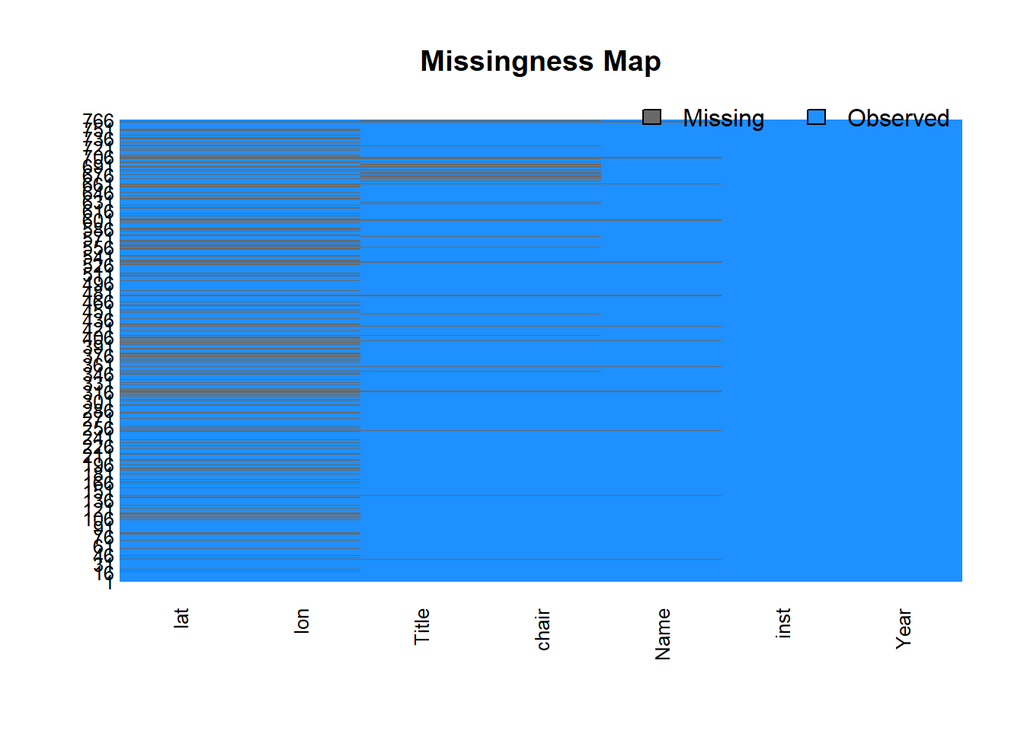

```r
g <- readRDS("c:/users/connor/Desktop/ASCScraping/Clean Grads2.rds")
g <- g %>% filter(Year>2002) %>%   filter(Year<2016)

missmap(g,col=c('dimgrey','dodgerblue'))
```

## Locations

Some of these locations were not properly geocoded. You can still see the volume in the New York area, Michigan, Omaha, and Los Angeles.

```r
gjs <- g %>%
  select(inst,lat,lon) %>%
  filter(!lon=='NA') %>%
  group_by(inst,lon=round(lon,5),lat=round(lat,5)) %>%
  summarise(num=n())


inst <- gjs %>% group_by(lon,lat) %>% arrange(-num) %>% filter(row_number()==1)


test <- left_join(gjs,inst,by=c('lon','lat')) %>%
  ungroup() %>%
  select(inst.y,lon,lat,num.y) %>%
  unique()




leaflet() %>%
  addProviderTiles("CartoDB.Positron") %>%
  #addTiles() %>%
  setView(lat=40.95,lng=-96.58,zoom=4) %>%
  addCircleMarkers(lng=~lon,lat=~lat,radius=~num.y/2,
                   data=test,
                   popup=~inst.y)
```

[interactive chart not shown]

## Wordcloud

It had to be done. These are trite plots, but also a good first step in examining text data. Perhaps not surprisingly, police (and related variants) is the most common term. And by a longshot.

```r
my_stop_words <- data.frame(word=c('univers','graduate','social','florida','houston',
                                     'michael','john','college','jay',
                                     'university','chaired','criminal','august','state',
                                     'may','december','crime','justice','the',
                                     'study','analysis','examination','and','the',
                                     '\\?','\\???','o','othe','use','among'))


gtidy <- g %>%
  dplyr::select(Title) %>%
  mutate(Title=as.character(Title)) %>%
  na.omit() %>%
  unnest_tokens(word,Title) %>%
  anti_join(stop_words) %>%
  anti_join(my_stop_words)
```

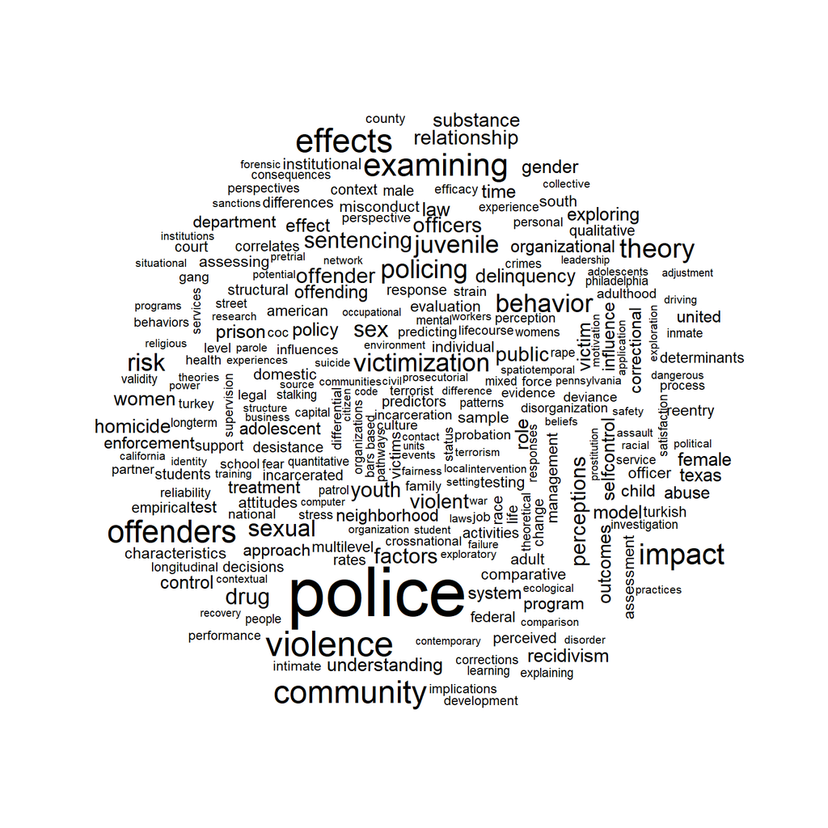

```r
gtidy %>%
  count(word) %>%
  with(wordcloud(word,n,max.words=250))
```

```r
  #findFreqTerms(term.matrix,20)


top20 <-
gtidy %>%
  count(word) %>%
  arrange(-n) %>%
  top_n(20)
top20
```

```
## # A tibble: 20 x 2
##    word              n
##    <chr>         <int>
##  1 police           83
##  2 violence         36
##  3 effects          33
##  4 community        32
##  5 examining        32
##  6 offenders        31
##  7 impact           28
##  8 theory           25
##  9 policing         24
## 10 behavior         23
## 11 victimization    23
## 12 juvenile         22
## 13 risk             22
## 14 sexual           20
## 15 drug             19
## 16 sentencing       19
## 17 sex              19
## 18 factors          18
## 19 officers         18
## 20 youth            18
```

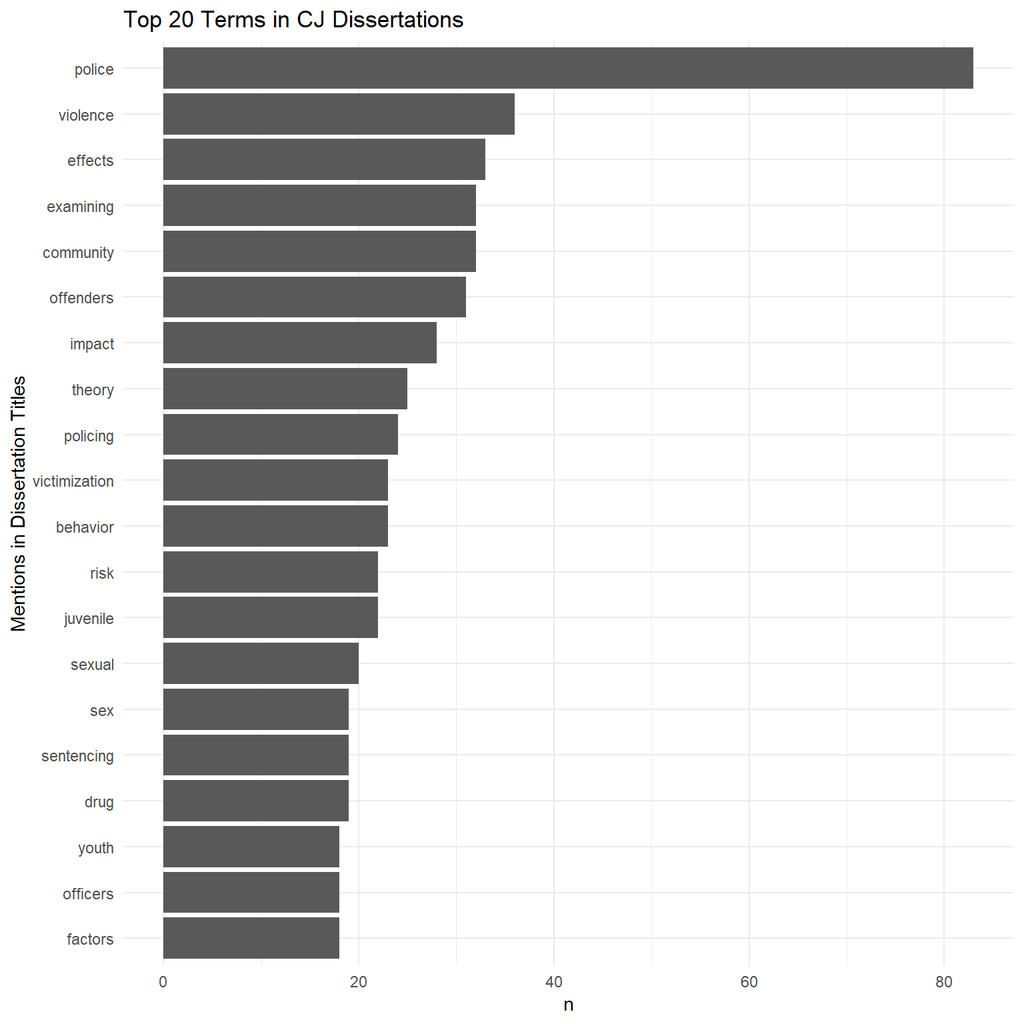

```r
top20 %>%
  mutate(word=reorder(word,n)) %>%
  ggplot(aes(word,n))+geom_bar(stat='identity')+
  coord_flip()+
  theme_minimal()+
  labs(title='Top 20 Terms in CJ Dissertations',
       x='Mentions in Dissertation Titles')
```

## Word Association

```r
ds <- VectorSource(na.omit(as.character(g$Title)))



  term.matrix <- TermDocumentMatrix(Corpus(ds),
                     control=list(removePunctuation=T,
                                  tolower=T,
                                  removeNumbers=T,
                                  stopwords=T))


findAssocs(term.matrix,"risk",.2)
```

```
## $risk
##       instrument       labyrinths       structured       additional
##             0.40             0.40             0.40             0.40
##    researchbased           static       assessment   implementation
##             0.40             0.40             0.32             0.28
##    vulnerability          improve      statistical             fear
##             0.28             0.28             0.28             0.27
##          factors       recidivism      negotiating lifestyleroutine
##             0.25             0.22             0.22             0.22
##       predicting
##             0.21
```

```r
findAssocs(term.matrix,"police",.2)
```

```
## $police
##          contact disproportionate      generations       situations
##             0.32             0.30             0.30             0.30
##         officers       department         fairness            urban
##             0.25             0.25             0.24             0.22
##        diffusion       corruption          turkish
##             0.21             0.21             0.20
```

## Tidy Text

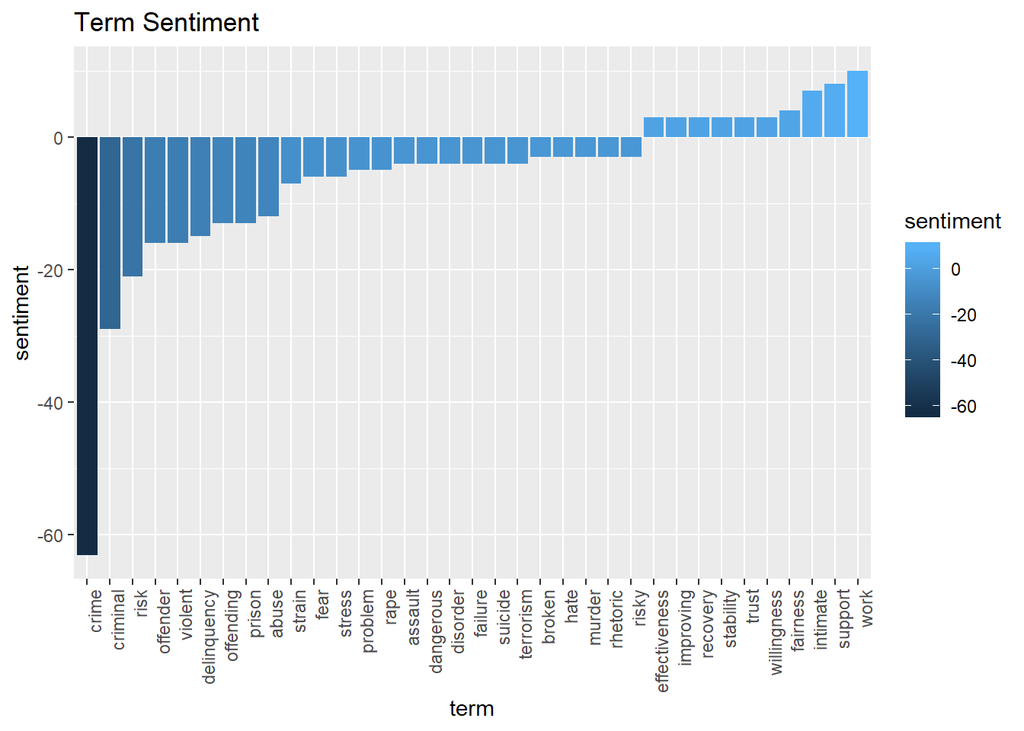

```r
bing <- sentiments %>%
  filter(lexicon=='bing') %>%
  select(-score)


sent <- tidy(term.matrix) %>%
  inner_join(bing, by=c(term='word')) %>%
  count(term,sentiment,wt=count) %>%
  arrange(-n) %>% filter(n>2) %>%
  ungroup() %>%
  spread(sentiment,n,fill=0) %>%
  mutate(sentiment=positive-negative) %>%
  arrange(sentiment)


sent %>%
  mutate(term=reorder(term,sentiment)) %>%
  ggplot(aes(term,sentiment,fill=sentiment))+geom_bar(stat='identity')+
  theme(axis.text.x=element_text(angle=90,hjust=1))+
  ggtitle('Term Sentiment')
```

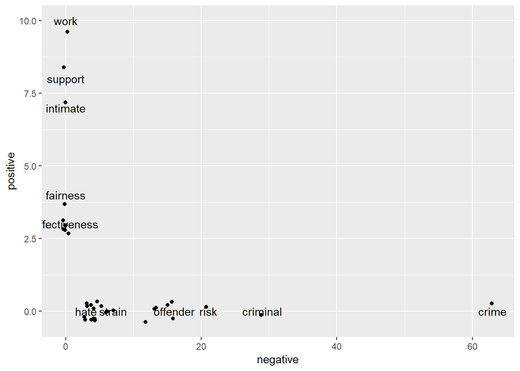

```r
  ggplot(sent,aes(x=negative,y=positive,group=term))+geom_jitter() +
  geom_text(aes(label=term),check_overlap = T)
```